# Ford GoBikes February Analysis

## by Emmaculate Wamboi

## Investigation Overview

Ford Gobikes system is wide bike shaing system and in this part i will like to look at the demand of bikes in timely basis. Also we well get to look at the different kind of members.

## Dataset Overview

This data explores the performance of the Ford GoBike data of the month of february 2019.

## 1.Ford GoBike Customers vs. Subscribers in 2019

During the year 2019 in the month of February, the subscribers were at 90.5% while the customers were at 9.5%.

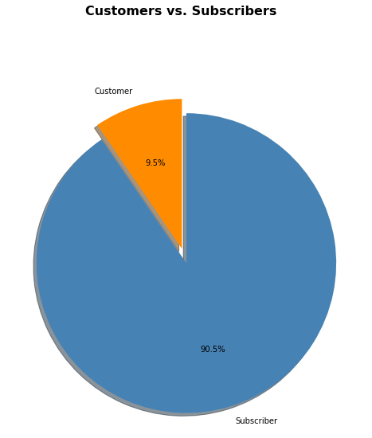

## 2. Ford GoBike Weekly usage

In the month of February, Thursday was the most popular day of the week recording high number of users which was followed by Tuesday .

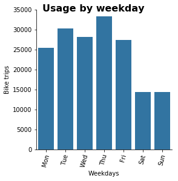

## 3.Ford GoBike duration in minutes

The data clearly indicates that customers use the bikes for a longer period of time which is between 6 to 18 minutes while on the other hand the subscribers tend to use for a shorter period of time that is between 5 to 13 minutes.

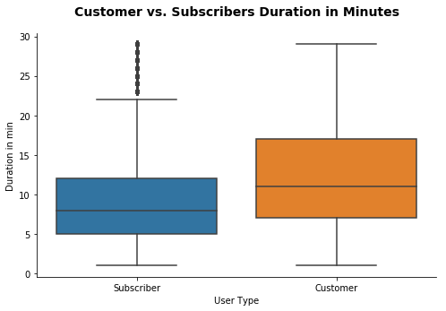

## Summary of the findings

The Ford GoBike system has two type of members that is the customers and the subscribers.After doing sme analysis theses were the findings:

```
- 90.5% of the bike users were subscribers and they were mostly commuters while 9.5% of the users were customers who
  mostly used for leisure purposes.
- The bikes were mostly used on Thursday which recorded a high number of users followed by Tuesday.
- Customers recorded longers trips more than subscribers.
```